# Organoid Size in MEK Inhibitors (Human)

Jan Sauer

24.10.2017

```r
library(PROMISE)
library(ggplot2)
config_dir = "/collab-ag-fischer/PROMISE/data-10x-4t-c-16z/configdir"
source(file.path(config_dir, "watchdogConfig.R"))

setwd("/Users/jansauer/Thesis/Projects/PROMISE/FeatureAnalysis/human/")
features = readRDS("QC_human__stability_selection__features.rds")
features_metadata = readRDS("QC_human__stability_selection__features_metadata.rds")
```

Load all layouts and find all drugs with MEK as a target

```r
all_layouts = unique(substr(rownames(features), 12, 14))
libs = setNames(
  object = vector(mode = "list", length = length(all_layouts)),
  nm = all_layouts)
for(layout in all_layouts) {
  libs[[layout]] = loadLibrary(layout, config_dir, c("Product.Name", "Target", "concentration"))
  libs[[layout]]$Product.Name = as.character(libs[[layout]]$Product.Name)
  libs[[layout]]$Target = as.character(libs[[layout]]$Target)
  if(!"concentration" %in% colnames(libs[[layout]]))
    libs[[layout]]$concentration = NA_real_
}
libs = do.call(rbind, libs)

mek_targets = libs[grep(pattern = "mek|map2k1|mapkk", x = libs$Target, ignore.case = TRUE), ]
```

# 1 Effect of Concentrations on L08

First, since L02/L03 and L08 use different concentrations, I want to know what, if any, impact they have on organoid size. L08 contains both Trametinib and Binimetinib as MEK-Inhibitors, so I look at the effects of both of these on the other plates (insofar as they are present on them).

```r
dmso_controls = features[features_metadata$DRUG == "DMSO", "organoids_num.of.objects"]
mek_targets_L08 = unique(mek_targets[substr(rownames(mek_targets), 1, 3) == "L08", "Product.Name"])
mek_indices_L08 = substr(rownames(features), 12, 14) == "L08" & features_metadata$DRUG %in% c("DMSO", mek_targets_L08)
features_L08 = features[mek_indices_L08, ]
metadata_L08 = features_metadata[mek_indices_L08, ]
simple_features_L08 = data.frame(
  "Avg.Organoid.Size" = features_L08$organoids_x.0.s.area_expected,
  "Num.Organoids" = features_L08$organoids_num.of.objects,
  "Total.Biomass" = features_L08$Total.Biomass,
  "Drug" = metadata_L08$DRUG,
  "Drug_Concentration" = ifelse(
    test = metadata_L08$DRUG == "DMSO", yes = metadata_L08$DRUG,
    no = paste0(metadata_L08$DRUG, " @ ", metadata_L08$CONCENTRATION)),
  "Cell.Line" = metadata_L08$CELL.LINE
)
```

```r
features_L02L03 = features[substr(rownames(features), 12, 14) %in% c("L02", "L03"), ]
metadata_L02L03 = features_metadata[substr(rownames(features), 12, 14) %in% c("L02", "L03"), ]
mek_targets_L02L03 = unique(grep(
  pattern = paste0(mek_targets_L08, collapse = "|"),
  x = metadata_L02L03$DRUG, value = TRUE))
features_L02L03 = features_L02L03[metadata_L02L03$DRUG %in% c("DMSO", mek_targets_L02L03), ]
metadata_L02L03 = metadata_L02L03[metadata_L02L03$DRUG %in% c("DMSO", mek_targets_L02L03), ]

simple_features_L02L03 = data.frame(
  "Avg.Organoid.Size" = features_L02L03$organoids_x.0.s.area_expected,
  "Num.Organoids" = features_L02L03$organoids_num.of.objects,
  "Total.Biomass" = features_L02L03$Total.Biomass,
  "Drug" = metadata_L02L03$DRUG,
  "Cell.Line" = metadata_L02L03$CELL.LINE
)
```

## 1.1 Trametinib (GSK1120212) on L02/L03

Note that there are only 2 replicates for each cell line so that the statistics are weak, at best.

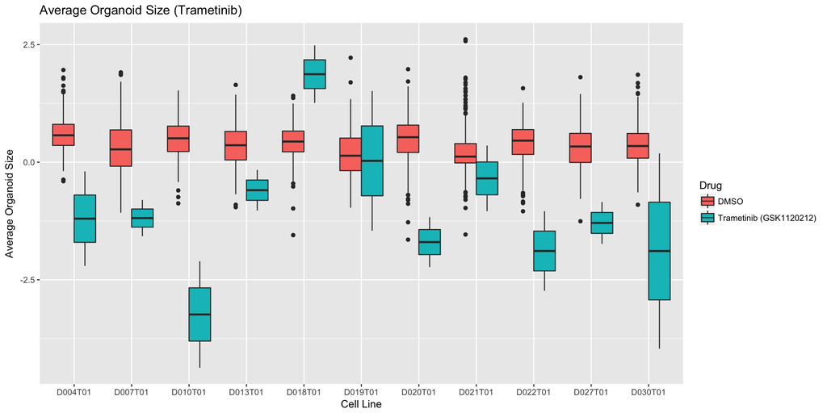

```r
ggplot(data = simple_features_L02L03) +
  geom_boxplot(aes(x = Cell.Line, y = Avg.Organoid.Size, fill = Drug)) +
  ggtitle(label = "Average Organoid Size (Trametinib)") + xlab("Cell Line") +
  ylab("Average Organoid Size")
```

## 1.2 Trametinib on L08

It seems that the concentrations 0.2 and 1 have similar effects and can be grouped together

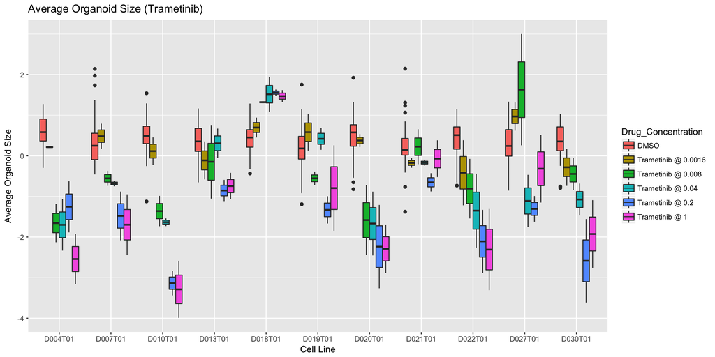

```r
ggplotdf = simple_features_L08[simple_features_L08$Drug %in% c("Trametinib", "DMSO"), ]
ggplot(data = ggplotdf) + geom_boxplot(aes(x = Cell.Line, y = Avg.Organoid.Size, fill = Drug_Concentration)) +
  ggtitle(label = "Average Organoid Size (Trametinib)") + xlab("Cell Line") +
  ylab("Average Organoid Size")
```

# 2 Combining Trametinib wells

I combine all Trametinib wells from plates L02/L03 and those with concentrations 0.2 or 1.0 from plate L08 to improve the statistics

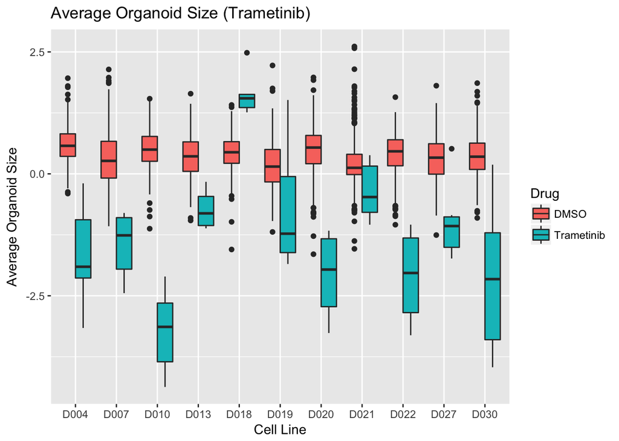

```r
valid_indices_L08 = metadata_L08$DRUG == "DMSO" | (
  metadata_L08$DRUG == "Trametinib" & metadata_L08$CONCENTRATION %in% c(0.2, 1.0))
features_L08 = features_L08[valid_indices_L08, ]
metadata_L08 = metadata_L08[valid_indices_L08, ]
features_combined = rbind(features_L02L03, features_L08)
metadata_combined = rbind(metadata_L02L03, metadata_L08)
metadata_combined$DRUG[metadata_combined$DRUG == "Trametinib (GSK1120212)"] = "Trametinib"
simple_features_combined = data.frame(
  "Avg.Organoid.Size" = features_combined$organoids_x.0.s.area_expected,
  "Num.Organoids" = features_combined$organoids_num.of.objects,
  "Total.Biomass" = features_combined$Total.Biomass,
  "Drug" = metadata_combined$DRUG,
  "Cell.Line" = substr(metadata_combined$CELL.LINE, 1, 4)
)
ggplot(data = simple_features_combined) +
  geom_boxplot(aes(x = Cell.Line, y = Avg.Organoid.Size, fill = Drug)) +
  ggtitle(label = "Average Organoid Size (Trametinib)") + xlab("Cell Line") +
  ylab("Average Organoid Size")
```

# 3 All MEK-Inhibitors

I want to expand this analysis to include all MEK-Inhibitors, i.e. all drugs that target MEK1/MAP2K1. As before, I limit myself to drugs with a concentration of 0.2 and 1 for the L08 treatments.

```r
mek_inhibitors = mek_targets[
  is.na(mek_targets$concentration) |
    mek_targets$concentration %in% c(0.2, 1.0), ]

rowname_ids = paste0(
  substr(rownames(features), 12, 14), ".",
  substr(rownames(features), 16, 16), substr(rownames(features), 18, 19))
features_mek = rbind.data.frame(
  features[rowname_ids %in% rownames(mek_inhibitors), ],
  features[features_metadata$DRUG == "DMSO", ])
metadata_mek = rbind.data.frame(
  features_metadata[rowname_ids %in% rownames(mek_inhibitors), ],
  features_metadata[features_metadata$DRUG == "DMSO", ])
metadata_mek$DRUG[metadata_mek$DRUG != "DMSO"] = "MEK-Inhibitor"
```

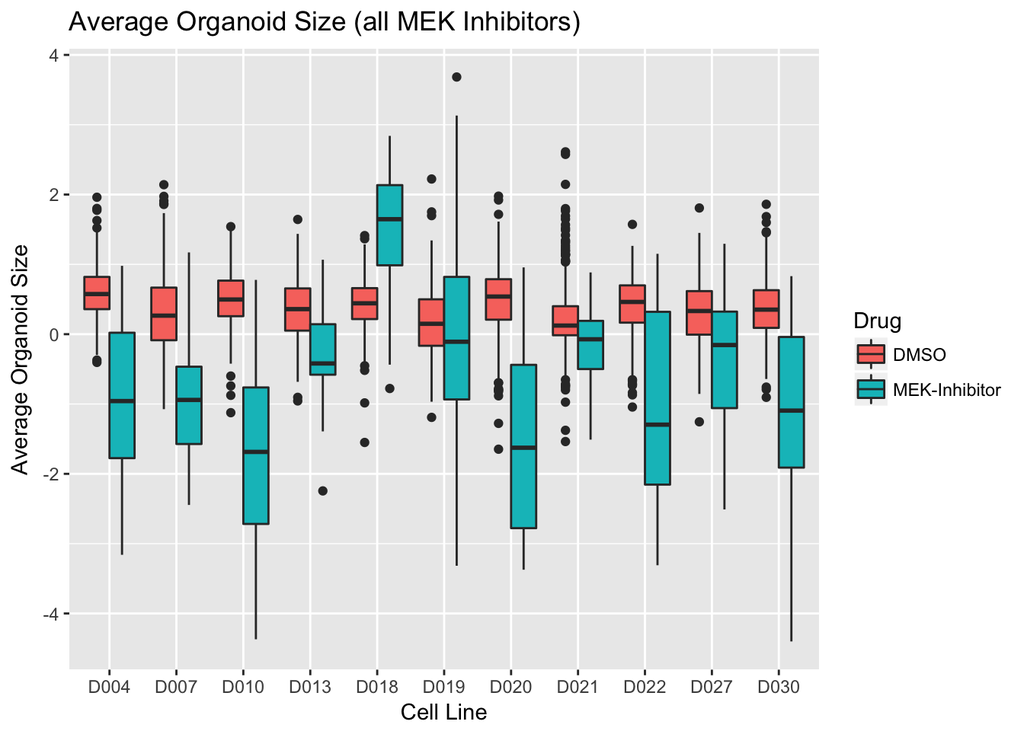

```r
simple_features_mek = data.frame(
  "Avg.Organoid.Size" = features_mek$organoids_x.0.s.area_expected,
  "Num.Organoids" = features_mek$organoids_num.of.objects,
  "Total.Biomass" = features_mek$Total.Biomass,
  "Drug" = metadata_mek$DRUG,
  "Cell.Line" = substr(metadata_mek$CELL.LINE, 1, 4)
)

ggplot(data = simple_features_mek) +
  geom_boxplot(aes(x = Cell.Line, y = Avg.Organoid.Size, fill = Drug)) +
  ggtitle(label = "Average Organoid Size (all MEK Inhibitors)") + xlab("Cell Line") +
  ylab("Average Organoid Size")
```